# P4

## Pregunta 4: ¿Existe una relación entre costo de carrera y otras variables?

**Esta pregunta está mayormente respondida y diseñada por Adriana Concha**

### Metodología

Siguiendo la sugerencia del cuerpo docente para el Hito 2 y aplicando las nuevas técnicas de minería de datos aprendidas en el curso desde entonces, se decidió responder esta pregunta utilizando **Reglas de asociación**. En la iteración anterior se propuso utilizar clustering, sin embargo, la búsqueda de reglas de asociación se adapta mejor a la búsqueda de relaciones entre variables. El objetivo de esta pregunta es extraer reglas y relaciones entre la variable valor del arancel y otras variables de las matrículas de educación superior , para poder realizar un análisis sobre éstas.

Propuesta experimental:

- Se toma como input los datos para el año 2019, filtrando valores faltantes.
- Se seleccionan los atributos: `jornada`, `rango_edad`,`dur_total_carr`,`tipo_inst_3`,`area_conocimiento`, `region_sede`, `acreditada_inst`, `valor_arancel`, `valor_matricula`.
- Se categoriza el valor de arancel en tres parámetros:
  - Percentil 0 al 32: Arancel bajo (AB)
  - Percentil 33 al 66: Arancel medio (AM)
  - Percentil 67 al 100: Arancel alto (AA)
- Se categoriza el valor de la matrícula en tres parámetros:
  - Percentil 0 al 32: Matrícula baja (MB)
  - Percentil 33 al 66: Matrícula media (MM)
  - Percentil 67 al 100: Matrícula alta (MA)
- Se utiliza el algoritmo ECLAT para obtener los itemsets más frecuentes, con **support** sobre 4%.
- Se utiliza el **algoritmo apriori** para generar reglas de asociación sobre los itemsets más frecuentes. Específicamente, se buscan reglas de asociación con cada categoría de Arancel en el consecuente. Se utiliza el parámetro minlen igual a 2, para encontrar reglas de al menos 2 elementos.
- Se utiliza como validación las métricas **support** sobre 4% y **confidence** sobre 30%. Además, se ordenan las reglas generadas de acuerdo a su **lift**, para conocer la efectividad de las predicciones. Para esta pregunta, nos interesan aquellas reglas con lift superior a 1.
- A partir de los resultados obtenidos, se generan las siguientes visualizaciones:
  - Scatterplots para comparar confidence, support y lift para las reglas generadas.
  - Grafos para visualizar los principales items que llevan a cada categoría de arancel.

### Implementación

La implementación en detalle de esta pregunta se puede ver en *Anexos, Implementación, Pregunta 4*. Se utilizaron 1268504 registros para el año 2019, añadiendo las categorías para valor de arancel y de matrícula.

| jornada | rango_edad | dur_total_carr | tipo_inst_3 | area_conocimiento | region_sede | acreditada_inst | Categoria_arancel | Categoria_matricula |
| --- | --- | --- | --- | --- | --- | --- | --- | --- |
| Diurno | 15 a 19 años | 10 | Universidades Privadas | Salud | Coquimbo | ACREDITADA | AM | MA |
| Diurno | 20 a 24 años | 10 | Universidades Estatales CRUCH | Ciencias Sociales | Metropolitana | ACREDITADA | AA | MM |
| Diurno | 25 a 29 años | 10 | Universidades Privadas CRUCH | Humanidades | Metropolitana | ACREDITADA | AA | MB |
| Vespertino | 15 a 19 años | 5 | Institutos Profesionales | Administración y Comercio | Metropolitana | NO ACREDITADA | AB | MB |
| Vespertino | 20 a 24 años | 5 | Institutos Profesionales | Administración y Comercio | Metropolitana | ACREDITADA | AB | MM |
| Diurno | 20 a 24 años | 10 | Universidades Estatales CRUCH | Tecnología | Metropolitana | ACREDITADA | AA | MM |

Se obtuvieron los siguientes items más frecuentes con el algoritmo ECLAT.

| items | support | count |
| --- | --- | --- |
| {ACREDITADA} | 0.93 | 1174652 |
| {Diurno} | 0.70 | 892899 |
| {ACREDITADA,Diurno} | 0.68 | 860341 |
| {Metropolitana} | 0.48 | 613381 |
| {20 a 24 años} | 0.47 | 598695 |
| {20 a 24 años,ACREDITADA} | 0.46 | 578644 |

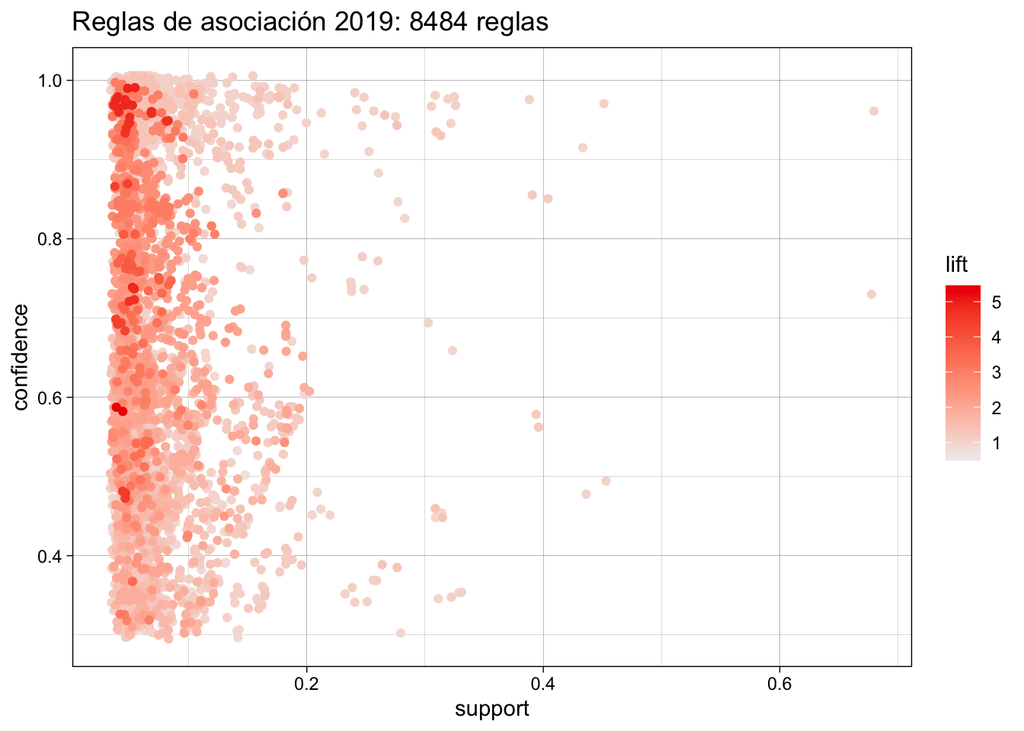

Dentro de las reglas generadas, se identificaron las siguientes reglas que llevan como consecuente a un Arancel Alto. Por ejemplo, de esto se puede concluir con un 4% de support y 92% de confidence, que una matrícula en una Universidad Privada, Acreditada, Diurna, en el área de la Salud con una Matrícula alta, lleva a tener un Arancel Alto. Esto con un lift de 2.76.

| rules | support | confidence | coverage | lift | count |
| --- | --- | --- | --- | --- | --- |
| {ACREDITADA,Diurno,MA,Salud,Universidades Privadas} => {AA} | 0.04 | 0.92 | 0.05 | 2.76 | 56737 |
| {Diurno,MA,Salud,Universidades Privadas} => {AA} | 0.05 | 0.92 | 0.05 | 2.75 | 58413 |
| {10,ACREDITADA,Diurno,MA,Metropolitana} => {AA} | 0.05 | 0.91 | 0.06 | 2.73 | 66365 |
| {ACREDITADA,MA,Salud,Universidades Privadas} => {AA} | 0.05 | 0.91 | 0.05 | 2.73 | 57557 |
| {10,ACREDITADA,MA,Metropolitana} => {AA} | 0.05 | 0.91 | 0.06 | 2.72 | 69277 |
| {10,ACREDITADA,Diurno,MA,Metropolitana,Universidades Privadas} => {AA} | 0.04 | 0.90 | 0.05 | 2.70 | 55948 |

Por otra parte, se identificaron las siguientes reglas que implican un Arancel Bajo. Por ejemplo, con un lift de 3, support 4% y confidence 100%, se puede concluir que una matrícula en una carrera de 5 años, en un Instituto Profesional con matrícula baja, implicará un Arancel Bajo.

| rules | support | confidence | coverage | lift | count |
| --- | --- | --- | --- | --- | --- |
| {5,Institutos Profesionales,MB} => {AB} | 0.04 | 1.00 | 0.04 | 3.00 | 54192 |
| {5,Centros de Formación Técnica,MB} => {AB} | 0.05 | 0.99 | 0.05 | 2.97 | 63287 |
| {5,ACREDITADA,Centros de Formación Técnica,MB} => {AB} | 0.04 | 0.99 | 0.04 | 2.97 | 55721 |
| {5,Diurno,MB} => {AB} | 0.05 | 0.99 | 0.05 | 2.97 | 62959 |
| {5,ACREDITADA,Diurno,MB} => {AB} | 0.04 | 0.99 | 0.04 | 2.96 | 54118 |
| {5,MB} => {AB} | 0.10 | 0.98 | 0.11 | 2.96 | 131416 |

En la siguiente visualización, se pueden ver las relaciones entre las Top 50 reglas generadas, con mayor lift, para consecuente Arancel Bajo. Se observa que los mayores lift se obtienen a partir de precedentes Área: Administración y Comercio, Matrícula baja y Centros de formación técnica. Los métodos A Distancia, a pesar de su bajo support, también presentan un lift alto para generar Arancel Bajo.

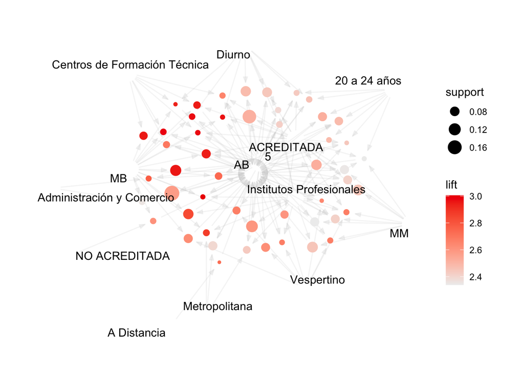